# Public support for global vaccine sharing in the COVID-19 pandemic: Evidence from Germany: Replication file

Ferdinand Geißler, Humboldt

Felix Hartmann, Humboldt

Macartan Humphreys, WZB and Columbia University

Heike Klüver, Humboldt

Johannes Giesecke, Humboldt

January 2022

The `.Rmd` file (code) for this replication file together with underlying data is available at: https://github.com/wzb-ipi/vaccine_solidarity

# 1 Setup

```r
knitr::opts_chunk$set(echo=TRUE, warning=FALSE, message=FALSE, comment=NA)
# options(qwraps2_markup = "markdown")

## Packages
if (!require(pacman)) install.packages("pacman")
pacman::p_load(
  ggpubr,      # for ggarrange
  cregg,       # conjoint
  estimatr,
  haven,       # load sav
  kableExtra,  # Prettier RMarkdown (1.0.1)
  knitr,
  labelled,
  sjlabelled,
  stargazer,
  texreg,
  tidyverse
)

# Whether to run from raw data
prep_data <- FALSE
```

# 2 Data preparation

```r
deal_labels <- c("No deal" =0,
                 "20 give 20 bn" = 1,
                 "40 give 20b" = 2,
                 "20 give 40 bn" = 3,
                 "40 give 40 bn" = 4)

# vignettes values

vign_values <-
  expand.grid(trading_importance = 0:1, risk=0:1, deal=0:4) %>%
  arrange(trading_importance, risk) %>%
  set_value_labels(
    trading_importance =
      c('Control: Wirtschaft bleibt unberührt'=0,
        'Treatment: Wirtschaft schrumpft um 5%'=1),
    risk=c('Control: Kein Risiko durch Mutationen'=0,
           'Treatment: Erhöhtes Risiko durch Mutationen'=1),
    deal= deal_labels) %>%
  mutate(vignr=1:20) %>%
  as_tibble()


head(vign_values) |>
  kable(caption = "Conditions", format = "pipe")
```

Conditions

| trading_importance | risk | deal | vignr |
| --- | --- | --- | --- |
| 0 | 0 | 0 | 1 |
| 0 | 0 | 1 | 2 |
| 0 | 0 | 2 | 3 |
| 0 | 0 | 3 | 4 |
| 0 | 0 | 4 | 5 |
| 0 | 1 | 0 | 6 |

```r
if(prep_data){

main_df <- read_csv('1_input/combined.csv') %>%
  mutate(
    party = factor(party_id, 1:9,
                   c("CDU.CSU", "CDU.CSU",
                     "SPD", "AFD", "Greens",
                     "FDP", "Left", "Other",
                     "No party"))) %>%
  group_by(ID) %>%
  mutate(migration_background = mean(migration_background, na.rm = TRUE)) %>%
  ungroup()

df_2 <- dplyr::filter(main_df, wave == 2) |>
  select(ID, solidarity_behaviour, solidarity_attitude, treatment_video,
         starts_with("c_0031"),
         starts_with("c_0032"),
         starts_with("vignette"),
         starts_with("conjoint_"))

w4 <- main_df |>
  dplyr::filter(wave==4) |>
  select(group, ID,
         perspective_fed_indian, perspective_fed_german,
         vaccinated, party, migration_background,
         run1_exp8, exp7_money1, exp7_doses1,
         run2_exp8, exp7_money2, exp7_doses2)

df_4 <-

  list(

    w4 %>%
      mutate(vignr = as.numeric(run1_exp8), round = 1) |>
      rename(cash =     exp7_money1, doses = exp7_doses1),

    w4 %>%
      mutate(vignr = as.numeric(run2_exp8), round = 2) |>
      rename(cash =     exp7_money2, doses =  exp7_doses2)
    ) %>%

  bind_rows %>%

  left_join(vign_values) %>%

  dplyr::filter(group !=3) %>%

  mutate(id = ID,
         others_number = (deal==1 | deal == 3)*2 + (deal==2 | deal == 4)*4,
         others_giving = (deal==1 | deal == 2)*2 + (deal==3 | deal == 4)*4,
         others_average = others_giving/others_number,
         others_average = ifelse(others_number==0, 0, others_average),
         deal = factor(deal, deal_labels, names(deal_labels)),
         risk_factor = factor(risk, 0:1, c("Low", "High")),
         trading_factor = factor(trading_importance, 0:1, c("Low", "High")),
         risk = risk - mean(risk),
         trading_importance = trading_importance - mean(trading_importance),
         others_number_norm = others_number - mean(others_number),
         others_giving_norm = others_giving - mean(others_giving),
         cash_billions =    cash*1000,
         cash_billions_log =    log(1 + cash_billions)) |>
  left_join(df_2)



df_4  |> write_rds("df_4.rds")
df_2  |> write_rds("df_2.rds")


}

  df_4 <- read_rds("df_4.rds")
  df_2 <- read_rds("df_2.rds")
```

# 3 Numbers provided in Introduction (Vaccine background data from OWID)

```r
owd <- read.csv("1_input/owid-covid-data-20221007.csv")

owd_world <- filter(owd, location == "World")

owd <- owd  |>
     dplyr::filter(continent != "")

alt_date = "2022-10-01"
survey_date = "2021-09-22"

small_owd <- owd %>%
   dplyr::filter(date == survey_date) %>%
   select(iso_code, location, gdp_per_capita, population, people_fully_vaccinated_per_hundred, total_deaths_per_million, total_vaccinations)

small_owd_alt <- owd %>%
   dplyr::filter(date == alt_date) %>%
   select(iso_code, location, gdp_per_capita, population, people_fully_vaccinated_per_hundred, total_deaths_per_million, total_vaccinations)
```

## 3.1 Global vaccination

```r
owd_world |>
  filter(date %in% c(survey_date, alt_date)) |>
  select(date, people_fully_vaccinated_per_hundred, total_vaccinations) |>
  kable(caption = "Vaccination at the time of survey and most recently", format = "pipe")
```

Vaccination at the time of survey and most recently

| date | people_fully_vaccinated_per_hundred | total_vaccinations |
| --- | --- | --- |
| 2021-09-22 | 32.18 | 6065656204 |
| 2022-10-01 | 62.71 | 12774122923 |

## 3.2 Historical distribution as explained by GDP and by deaths

```r
r2s <- c(
  r2_gdp = lm_robust(
  people_fully_vaccinated_per_hundred ~  gdp_per_capita,
  data = small_owd)$r.squared,

  r2_deaths = lm_robust(
  people_fully_vaccinated_per_hundred ~  total_deaths_per_million,
  data = small_owd)$r.squared,

  r2_deaths_most_recent = lm_robust(
  people_fully_vaccinated_per_hundred ~  total_deaths_per_million,
  data = small_owd_alt)$r.squared)

data.frame(var = names(r2s), R2 = r2s)|> kable(format = "pipe")
```

|  | var | R2 |
| --- | --- | --- |
| r2_gdp | r2_gdp | 0.5633888 |
| r2_deaths | r2_deaths | 0.0778412 |
| r2_deaths_most_recent | r2_deaths_most_recent | 0.0344874 |

## 3.3 Coverage in top 10 and bottom 10 countries (with data and population > 500,000)

```r
small_owd |>
  arrange(people_fully_vaccinated_per_hundred) |>
  filter(!is.na(people_fully_vaccinated_per_hundred) &
           population > 500000) |>
  mutate(N = n()) |>
  select(location, people_fully_vaccinated_per_hundred, N) |>
  slice(10, (n()-9)) %>%
  kable(caption = "Most and least vaccinated", format = "pipe")
```

Most and least vaccinated

| location | people_fully_vaccinated_per_hundred | N |
| --- | --- | --- |
| Kenya | 1.64 | 102 |
| Chile | 72.28 | 102 |

```r
small_owd_alt |>
  arrange(people_fully_vaccinated_per_hundred) |>
  filter(!is.na(people_fully_vaccinated_per_hundred) &
           population > 500000) |>
  mutate(N = n()) |>
  select(location, people_fully_vaccinated_per_hundred, N) |>
  slice(10, (n()-9)) %>%
  kable(caption = "Most and least vaccinated, most recent---note few countries reporting", format = "pipe")
```

Most and least vaccinated, most recent—note few countries reporting

| location | people_fully_vaccinated_per_hundred | N |
| --- | --- | --- |
| Israel | 66.24 | 36 |
| Canada | 82.77 | 36 |

### 3.3.1 Assessed shares

```r
pc <- 80000000000/ (small_owd %>% dplyr::filter(gdp_per_capita > 27000) %>% pull(population) %>% sum)

small_owd <- small_owd %>% mutate(
  bill = ifelse(gdp_per_capita > 27000, pc*population, 0)
)

small_owd %>%
  dplyr::filter(location == "Germany" | location == "United States" ) %>%
  kable(format = "pipe")
```

| iso_code | location | gdp_per_capita | population | people_fully_vaccinated_per_hundred | total_deaths_per_million | total_vaccinations | bill |
| --- | --- | --- | --- | --- | --- | --- | --- |
| DEU | Germany | 45229.25 | 83408554 | 63.26 | 1116.468 | 108284950 | 5818540801 |
| USA | United States | 54225.45 | 336997624 | 56.73 | 2016.174 | 395249407 | 23508792935 |

# 4 Analysis: Raw patterns

```r
# Support sizes

amounts_d <- seq(0, 22, .5)
amounts_v <- seq(0, 200, 1)

# Figures cumulative distribution
support <- function(x = df_4$cash_billions, amounts = amounts_d)
  data.frame(
    amounts = amounts,
    support = sapply(amounts, function(j)
      mean(x >= j, na.rm = TRUE)))

s1 <- list(
  Low = support(
    df_4 %>% dplyr::filter(risk_factor == "Low" & trading_factor == "Low") %>% pull(cash_billions),
    amounts = amounts_d),
  High  =  support(
    df_4 %>% dplyr::filter(risk_factor == "High" & trading_factor == "High")%>% pull(cash_billions), amounts = amounts_d)) %>%
  bind_rows(.id = "Costs")

s2 <- list(
  Low = support(
    df_4 %>% dplyr::filter(deal == "No deal") %>% pull(cash_billions)),
  High  =  support(
    df_4 %>% dplyr::filter(deal == "40 give 40 bn") %>% pull(cash_billions))) %>%
  bind_rows(.id = "Multilateralism")


s3 <- list(
  Low = support(
    df_4 %>% dplyr::filter(risk_factor == "Low" & trading_factor == "Low") %>% pull(doses), amounts_v),
  High  =  support(
    df_4 %>% dplyr::filter(risk_factor == "Low" & trading_factor == "High") %>% pull(doses), amounts_v)) %>%
  bind_rows(.id = "Costs")

s4 <- list(
  Low = support(
    df_4 %>% dplyr::filter(deal == "No deal") %>% pull(doses), amounts_v),
  High  =  support(
    df_4 %>% dplyr::filter(deal == "40 give 40 bn") %>% pull(doses), amounts_v)) %>%
  bind_rows(.id = "Multilateralism")
```

# 5 Figure 1: Distribution of support for contributions of different sizes

```r
supports <-
  ggarrange(
    s1 %>% ggplot(aes(amounts, support, color = Costs)) + geom_line() + ylim(0, 1) +
      theme_bw() +
      xlab("German contribution (bn Euro)") + ylab("Share supporting")  +
      theme(legend.position = "bottom"),

    s2 %>% ggplot(aes(amounts, support, color = Multilateralism)) + geom_line() + ylim(0, 1) +
      theme_bw() +
      xlab("German contribution (bn  Euro)") +
      ylab("Share supporting")   +
      theme(legend.position = "bottom") + ylab(""),

    s3 %>% ggplot(aes(amounts, support, color = Costs)) + geom_line() + ylim(0, 1) + theme_bw() + xlab("German contribution (mio vaccines)") + ylab("Share supporting")  + theme(legend.position = "bottom"),

    s4 %>% ggplot(aes(amounts, support, color = Multilateralism)) + geom_line() + ylim(0, 1) + theme_bw() + xlab("German contribution (mio vaccines)") + ylab("Share supporting")   + theme(legend.position =  "bottom") + ylab(""),

    nrow = 2,
    ncol = 2
  )

pdf("2_output/cumulative.pdf", height = 6, width = 10)
 supports
dev.off()
```

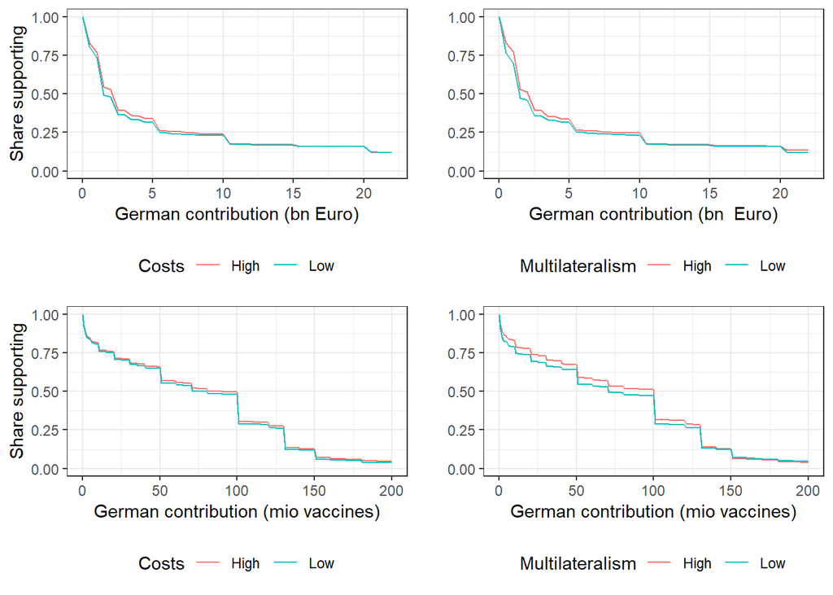

```r
supports
```

Basic variation by vaccination status

```r
df_4 %>% group_by(vaccinated) %>%
  summarize(median_cash = median(cash_billions),
            mean_cash = mean(cash_billions),
            median_doses = median(doses),
            mean_doses = mean(doses),
            ) |>
  kable(format = "pipe")
```

| vaccinated | median_cash | mean_cash | median_doses | mean_doses |
| --- | --- | --- | --- | --- |
| 0 | 1 | 8.387918 | 50 | 64.92555 |
| 1 | 2 | 8.724218 | 100 | 80.48265 |

```r
main_results <-
  list(
  cash = lm_robust(cash_billions ~ trading_importance*risk*others_number_norm*others_giving_norm  + round, fixed_effects = ~id,  se_type = "stata", data = df_4) %>% tidy,
  doses = lm_robust(doses ~ trading_importance*risk*others_number_norm*others_giving_norm  + round, fixed_effects = ~id,  se_type = "stata", data = df_4) %>% tidy) %>% bind_rows()


 treatments <- c("trading_importance", "risk", "others_number", "others_giving")
 treatments_norm <- c("trading_importance", "risk", "others_number_norm", "others_giving_norm")

 treatment_labels <- c("Trading importance", "Risk", "Number of others giving (10s)", "Amount given by other countries\n(10s of billions)")
```

Basic variation by risk factor

```r
df_4 %>% group_by(risk_factor) %>%
  summarize(
  median_cash = median(cash_billions),
  mean_cash = mean(cash_billions),
  median_doses = median(doses),
  mean_doses = mean(doses)) |>
  kable(format = "pipe")
```

| risk_factor | median_cash | mean_cash | median_doses | mean_doses |
| --- | --- | --- | --- | --- |
| Low | 1.15 | 8.346641 | 80 | 76.06485 |
| High | 2.00 | 8.994930 | 100 | 79.93953 |

# 6 Figure 2: Marginal effects of conditions

The average proposal is: 8.67 billion Euros and 78 million doses.

The median proposal is: 2 billion Euros and 90 million doses.

These are close to actual https://www.auswaertiges-amt.de/en/aussenpolitik/themen/gesundheit/covax/2396914.

The median in risk conditions is proposal is: 2 billion Euros and 100 million doses.

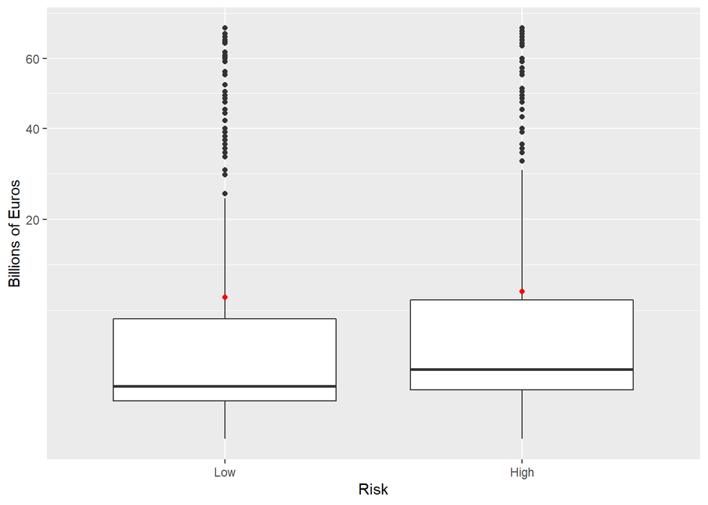

```r
figure_2 <-

  main_results %>%
  dplyr::filter(term %in% treatments_norm) %>%
  mutate(Treatment = factor(term, treatments_norm, treatment_labels),
         outcome = factor(outcome, c("cash_billions", "doses"), c("Cash (billion Euros)", "Doses (Millions)"))) %>%

  ggplot(aes(estimate, Treatment)) + geom_point()+
  geom_errorbar(aes(xmin = conf.low, xmax = conf.high), width = .1)+
  geom_vline(xintercept=0, linetype="longdash", lwd=0.35, colour = "#B55555") +
  theme_bw() + facet_grid(~outcome, scales = "free_x")+
  ylab("")


df_mean <- df_4 %>%
  group_by(risk_factor) %>%
  summarize(average = mean(cash_billions, na.rm = TRUE)) %>%
  ungroup()

figure_2_1 <-
  df_4 %>%
  ggplot(aes(risk_factor, cash_billions)) +
  geom_boxplot() + ylab("Billions of Euros")   + xlab("Risk")  + scale_y_sqrt() +
  geom_point(data = df_mean,
             mapping = aes(x = risk_factor, y = average),
             color="red")

figure_2_2 <-
  df_4 %>%
  ggplot(aes(risk_factor, doses)) +
  geom_boxplot() + ylab("Millions of doses") + xlab("Risk")

figure_2_1
```

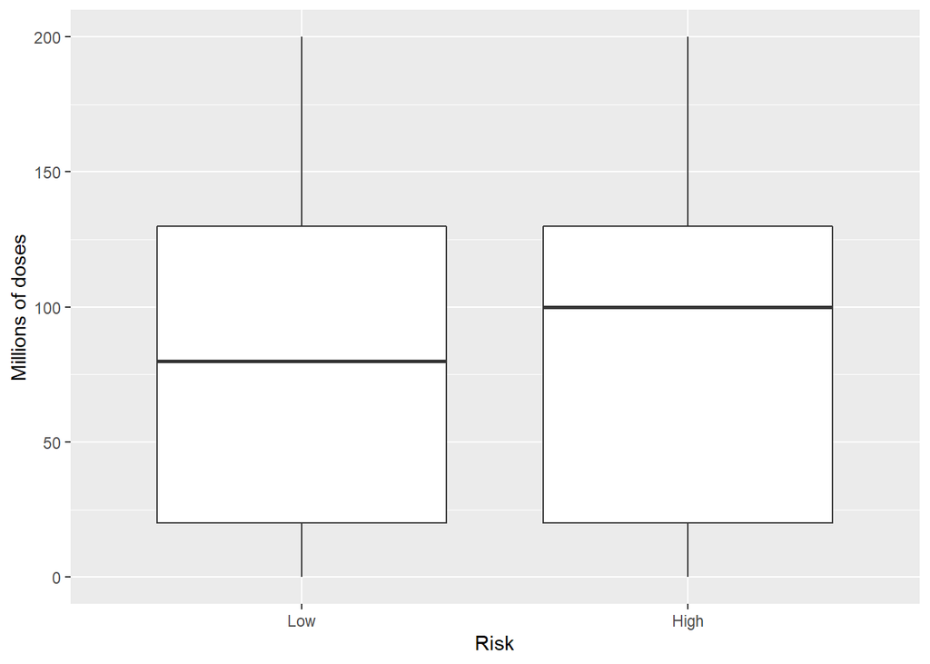

```r
figure_2_2
```

Note that the doses options was limited to between 0 and 200 m.

Offers are responsive to risk and economic impacts but not much to coordination considerations.

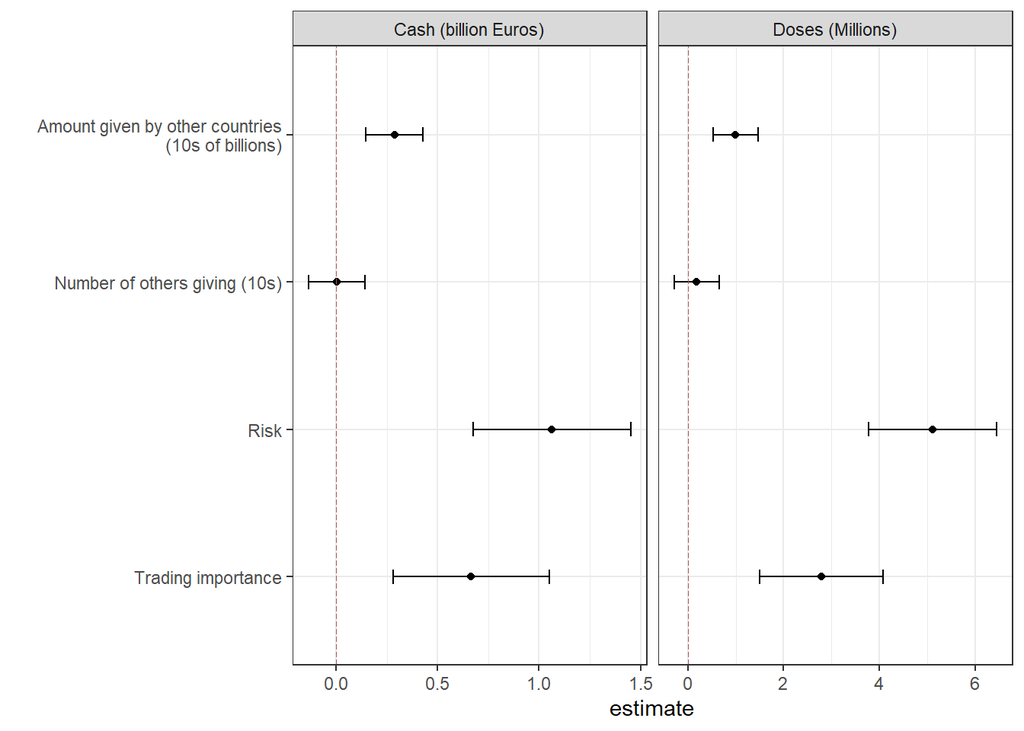

```r
figure_2
```

```r
pdf("2_output/E1_main.pdf", width = 6, height = 3)
figure_2
dev.off()
```

Trading importance and risk are substitutes for cash but not doses.

Without demeaning:

```r
lm_robust(cash_billions ~ trading_factor*risk_factor+ round, fixed_effects = ~id,  se_type = "stata", data = df_4) %>% tidy  %>%
  kbl(digit =2) %>%
  kable_minimal()
```

| term | estimate | std.error | statistic | p.value | conf.low | conf.high | df | outcome |
| --- | --- | --- | --- | --- | --- | --- | --- | --- |
| trading_factorHigh | 0.83 | 0.23 | 3.54 | 0.00 | 0.37 | 1.29 | 10521 | cash_billions |
| risk_factorHigh | 1.64 | 0.24 | 6.94 | 0.00 | 1.18 | 2.11 | 10521 | cash_billions |
| round | 0.01 | 0.12 | 0.10 | 0.92 | -0.22 | 0.24 | 10521 | cash_billions |
| trading_factorHigh:risk_factorHigh | -0.65 | 0.32 | -2.01 | 0.04 | -1.28 | -0.02 | 10521 | cash_billions |

Logging helps and substitution not as strong:

```r
lm_robust(log(cash_billions+1) ~ trading_factor*risk_factor+ round, fixed_effects = ~id,  se_type = "stata", data = df_4) %>% tidy  %>%
  kbl(digit =2) %>%
  kable_minimal()
```

| term | estimate | std.error | statistic | p.value | conf.low | conf.high | df | outcome |
| --- | --- | --- | --- | --- | --- | --- | --- | --- |
| trading_factorHigh | 0.10 | 0.01 | 6.76 | 0.00 | 0.07 | 0.13 | 10521 | log(cash_billions + 1) |
| risk_factorHigh | 0.16 | 0.01 | 10.80 | 0.00 | 0.13 | 0.19 | 10521 | log(cash_billions + 1) |
| round | 0.02 | 0.01 | 2.10 | 0.04 | 0.00 | 0.03 | 10521 | log(cash_billions + 1) |
| trading_factorHigh:risk_factorHigh | -0.05 | 0.02 | -2.34 | 0.02 | -0.09 | -0.01 | 10521 | log(cash_billions + 1) |

## 6.1 Full results from saturated models

```r
main_results %>%
  kbl(digit =2) %>%
  kable_minimal()
```

| term | estimate | std.error | statistic | p.value | conf.low | conf.high | df | outcome |
| --- | --- | --- | --- | --- | --- | --- | --- | --- |
| trading_importance | 0.67 | 0.20 | 3.38 | 0.00 | 0.28 | 1.05 | 10509 | cash_billions |
| risk | 1.06 | 0.20 | 5.37 | 0.00 | 0.68 | 1.45 | 10509 | cash_billions |
| others_number_norm | 0.00 | 0.07 | 0.05 | 0.96 | -0.14 | 0.14 | 10509 | cash_billions |
| others_giving_norm | 0.29 | 0.07 | 4.01 | 0.00 | 0.15 | 0.43 | 10509 | cash_billions |
| round | 0.02 | 0.12 | 0.17 | 0.86 | -0.21 | 0.25 | 10509 | cash_billions |
| trading_importance:risk | -0.23 | 0.39 | -0.60 | 0.55 | -1.00 | 0.53 | 10509 | cash_billions |
| trading_importance:others_number_norm | 0.03 | 0.15 | 0.19 | 0.85 | -0.26 | 0.32 | 10509 | cash_billions |
| risk:others_number_norm | 0.05 | 0.14 | 0.35 | 0.73 | -0.23 | 0.33 | 10509 | cash_billions |
| trading_importance:others_giving_norm | -0.03 | 0.15 | -0.24 | 0.81 | -0.32 | 0.25 | 10509 | cash_billions |
| risk:others_giving_norm | -0.04 | 0.15 | -0.24 | 0.81 | -0.33 | 0.26 | 10509 | cash_billions |
| others_number_norm:others_giving_norm | -0.02 | 0.04 | -0.43 | 0.67 | -0.11 | 0.07 | 10509 | cash_billions |
| trading_importance:risk:others_number_norm | -0.30 | 0.28 | -1.08 | 0.28 | -0.86 | 0.25 | 10509 | cash_billions |
| trading_importance:risk:others_giving_norm | -0.02 | 0.30 | -0.06 | 0.95 | -0.60 | 0.56 | 10509 | cash_billions |
| trading_importance:others_number_norm:others_giving_norm | -0.12 | 0.08 | -1.38 | 0.17 | -0.28 | 0.05 | 10509 | cash_billions |
| risk:others_number_norm:others_giving_norm | 0.17 | 0.09 | 2.04 | 0.04 | 0.01 | 0.34 | 10509 | cash_billions |
| trading_importance:risk:others_number_norm:others_giving_norm | -0.29 | 0.17 | -1.68 | 0.09 | -0.62 | 0.05 | 10509 | cash_billions |
| trading_importance | 2.78 | 0.66 | 4.24 | 0.00 | 1.50 | 4.07 | 10509 | doses |
| risk | 5.11 | 0.68 | 7.52 | 0.00 | 3.78 | 6.44 | 10509 | doses |
| others_number_norm | 0.18 | 0.24 | 0.76 | 0.45 | -0.29 | 0.65 | 10509 | doses |
| others_giving_norm | 1.00 | 0.24 | 4.22 | 0.00 | 0.53 | 1.46 | 10509 | doses |
| round | 1.80 | 0.38 | 4.72 | 0.00 | 1.05 | 2.55 | 10509 | doses |
| trading_importance:risk | -0.67 | 1.24 | -0.54 | 0.59 | -3.10 | 1.76 | 10509 | doses |
| trading_importance:others_number_norm | 0.30 | 0.48 | 0.63 | 0.53 | -0.64 | 1.24 | 10509 | doses |
| risk:others_number_norm | 0.48 | 0.48 | 1.02 | 0.31 | -0.45 | 1.42 | 10509 | doses |
| trading_importance:others_giving_norm | 0.01 | 0.47 | 0.02 | 0.99 | -0.92 | 0.93 | 10509 | doses |
| risk:others_giving_norm | -0.58 | 0.48 | -1.20 | 0.23 | -1.51 | 0.36 | 10509 | doses |
| others_number_norm:others_giving_norm | -0.38 | 0.14 | -2.68 | 0.01 | -0.65 | -0.10 | 10509 | doses |
| trading_importance:risk:others_number_norm | 0.09 | 0.95 | 0.09 | 0.93 | -1.78 | 1.96 | 10509 | doses |
| trading_importance:risk:others_giving_norm | 0.34 | 0.97 | 0.35 | 0.73 | -1.56 | 2.23 | 10509 | doses |
| trading_importance:others_number_norm:others_giving_norm | -0.24 | 0.27 | -0.91 | 0.37 | -0.77 | 0.28 | 10509 | doses |
| risk:others_number_norm:others_giving_norm | 0.36 | 0.28 | 1.28 | 0.20 | -0.19 | 0.92 | 10509 | doses |
| trading_importance:risk:others_number_norm:others_giving_norm | -0.85 | 0.54 | -1.57 | 0.12 | -1.91 | 0.21 | 10509 | doses |

# 7 Table 2: Structural Analysis

We assume:

$$u = (a + bT + cR) \log(Y + x) - x^2 -
g(x - ky)^2$$

where $T$ is trading importance, $R$ is health risk, $Y$ is total Amount given by other countries and $y$ is average Amount given by other countries

First order condition for maximization is:

$$\frac{(a + bT + cR)}{ (Y + x)} - 2x -
2g(x - ky) = 0$$
This yields the following quadratic. We take the second solution (with positive contributions).

$$- 2(1+g)x^2- 2((1+g)Y - gky)x +(2gkyY+(a
+ bT + cR)) = 0$$

```r
# Quadratic solution
maxx <- function(a,b,c,g,k,ZT,ZR,ZY,Zy) {
  AA = -2*(1+g)
  BB = -2*((1+g)*ZY - g*k*Zy)
  CC = 2*g*k*Zy*ZY + a+b*ZT+c*ZR
  (-BB - (BB^2 - 4*AA*CC)^.5)/(2*AA)
}
maxx(a=1,b=1,c=1,g=1, k=1,ZT=1,ZR=1,ZY=1,Zy=1)
```

```
[1] 0.8956439
```

```r
lik_x <- function(x, sigma, a,b,c,g,k,ZT,ZR,ZY,Zy)
      dnorm(x,
            maxx(a, b, c, g, k, ZT, ZR, ZY, Zy),
            sd = sigma)

# Estimation

est <- function(data){

  LL  <- function(a=1,b=1,c=1,g=1,k=1, sigma=1) {

    R <- with(data,
          lik_x(x,
             sigma,
             a, b, c, g, k,
             ZT = trading_importance,
             ZR = risk,
             ZY = others_giving,
             Zy = others_average))

    -sum(log(R))
  }


  M <- bbmle::mle2(
    LL,
    # method = "L-BFGS-B",
    optimizer = "nlminb",
    start = list(a = 1, b = 1, c = 1, g = 2,  k = 1, sigma = .05),
    lower = list(a = -20, b = -10, c = -20, g = .01, k = -10, sigma = .02),
    upper = list(a = 20, b = 10, c = 10, g = 10, k = 10, sigma = 10))

  # Format output from estimation
  out <- bbmle::coef(bbmle::summary(M)) %>% data.frame()

  names(out) <- c("estimate", "std.error", "statistic", "p.value")

  out %>% mutate(conf.low = estimate - 1.96*std.error,
                 conf.high = estimate + 1.96*std.error)

}
```

Note structural estimates do not include fixed effects.

```r
# Note that starting values were found using  a grid search to approximate the region of the solution

df_4 <- df_4 %>% mutate(x = cash_billions)

  LL  <- function(a=1,b=1,c=1,g=1,k=1, sigma=1) {

    R <- with(df_4,
          lik_x(x,
             sigma,
             a, b, c, g, k,
             ZT = trading_importance,
             ZR = risk,
             ZY = others_giving,
             Zy = others_average))

    -sum(log(R))
  }

# .a    .b    .c    .g    .k  .sigma
# 243.   -10  36.7 0.667     5     16

M <- bbmle::mle2(
    LL,
    # method = "L-BFGS-B",
    optimizer = "nlminb",
    start = list(a = 240, b = -11, c = 41, g = .8,  k = 4, sigma = 16),
    lower = list(a = 0, b = -20, c = -60, g = .01, k = -10, sigma = .02),
    upper = list(a = 400, b = 20, c = 60, g = 5, k = 10, sigma = 30))

  # Format output from estimation
  out <- bbmle::coef(bbmle::summary(M)) %>% data.frame()

  names(out) <- c("estimate", "std.error", "statistic", "p.value")

  # Flag: Should be able to do better ci's than this
  out %>% mutate(conf.low = estimate - 1.96*std.error,
                 conf.high = estimate + 1.96*std.error) %>% kable(format = "pipe", digits = 2)
```

|  | estimate | std.error | statistic | p.value | conf.low | conf.high |
| --- | --- | --- | --- | --- | --- | --- |
| a | 240.62 | 2.01 | 119.73 | 0.00 | 236.68 | 244.56 |
| b | -10.32 | 12.71 | -0.81 | 0.42 | -35.23 | 14.59 |
| c | 37.79 | 12.45 | 3.04 | 0.00 | 13.40 | 62.19 |
| g | 0.61 | 0.07 | 9.22 | 0.00 | 0.48 | 0.75 |
| k | 5.22 | 0.40 | 13.06 | 0.00 | 4.44 | 6.00 |
| sigma | 15.98 | 0.08 | 205.18 | 0.00 | 15.83 | 16.14 |

```r
fileConn <- file("2_output/structural.tex")
writeLines(
  out %>% mutate(parameter = c("$\\alpha$", "$\\beta$", "$\\delta$", "$\\gamma$", "$\\kappa$", "$\\sigma$")) %>%
    relocate(parameter) %>%
    mutate(conf.low = estimate - 1.96*std.error,
                 conf.high = estimate + 1.96*std.error) %>%

    kable(format = "latex",
          caption = "Structural parameter estimates",
          digits = 2,
          booktabs = TRUE,
          label = "structural", row.names = FALSE,
          escape = FALSE,
          align = c("c", "r", "r", "r", "r", "r", "r")) %>%
    kable_styling(latex_options = "hold_position"),

  fileConn)

close(fileConn)
```

# 8 Figure 3: Effect of video treatment on individual solidarity

```r
outcomes <- c("solidarity_behaviour", "solidarity_attitude")
outcome_labels <- c("Solidarity Behavior", "Solidarity Attitude")
w2_treatments <- c("treatment_video")
w2_treatment_labels <- c("Treatment")
```

```r
df_2 %>% group_by(treatment_video, solidarity_behaviour) |>
  summarize(n = n()) |>
  filter(!is.na(solidarity_behaviour)) |>
  ungroup() |>
  group_by(treatment_video) |>
  mutate(share = n / sum(n)) |>
  kable(caption = "Raw data", format = "pipe")
```

Raw data

| treatment_video | solidarity_behaviour | n | share |
| --- | --- | --- | --- |
| 0 | 0.0 | 1821 | 0.2874961 |
| 0 | 0.2 | 537 | 0.0847805 |
| 0 | 0.4 | 1185 | 0.1870856 |
| 0 | 0.6 | 511 | 0.0806757 |
| 0 | 0.8 | 354 | 0.0558889 |
| 0 | 1.0 | 1926 | 0.3040733 |
| 1 | 0.0 | 1592 | 0.2600457 |
| 1 | 0.2 | 483 | 0.0788958 |
| 1 | 0.4 | 1070 | 0.1747795 |
| 1 | 0.6 | 477 | 0.0779157 |
| 1 | 0.8 | 383 | 0.0625613 |
| 1 | 1.0 | 2117 | 0.3458020 |

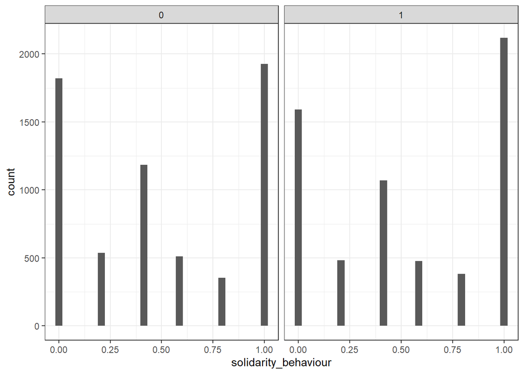

```r
#    keep           donate UNICEF
#1  0 Mingle Points 75 Mingle Points
#2 10 Mingle Points 60 Mingle Punkte
#3 20 Mingle Points 45 Mingle Points
#4 30 Mingle Points 30 Mingle Points
#5 40 Mingle Points 15 Mingle Points
#6 50 Mingle Points 0 Mingle Points

hist1<-df_2 %>%
  ggplot( aes(x = solidarity_behaviour)) +
  geom_histogram()+
  theme_bw() + facet_grid(~treatment_video)


hist2<-df_2 %>%
  ggplot( aes(x = solidarity_attitude)) +
  geom_histogram()+
  theme_bw()  + facet_grid(~treatment_video)

hist1
```

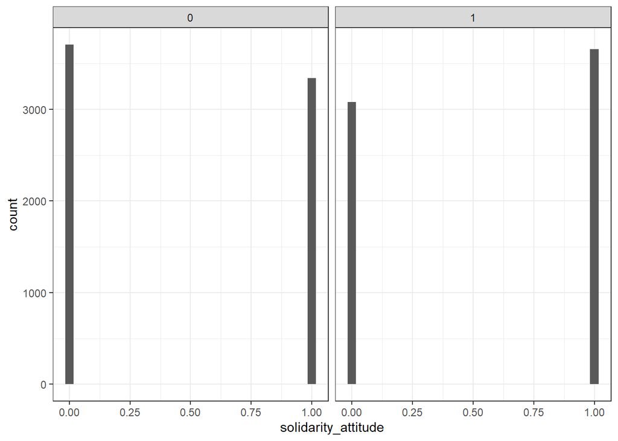

```r
hist2
```

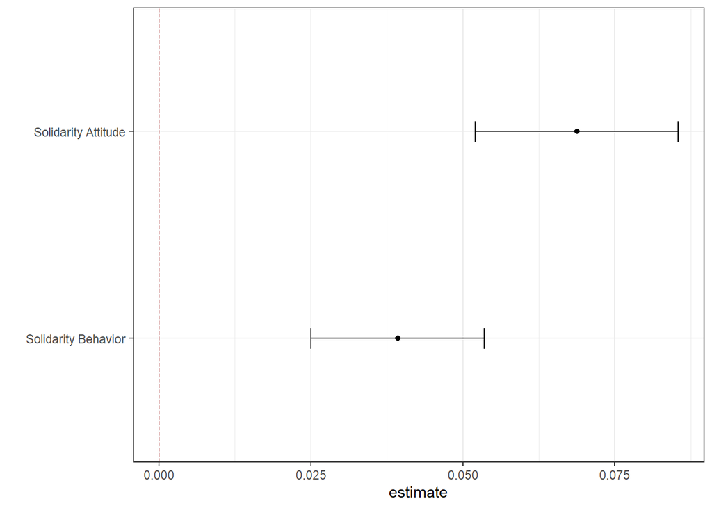

```r
models_basic <- lapply(c(outcomes), function(y)
lm_robust(as.formula(paste(y, "~ treatment_video")),
          data = df_2))
names(models_basic) <- outcomes


figure_3 <-
  lapply(models_basic, tidy) %>% bind_rows(.id = "outcome") %>%
  dplyr::filter(term != "(Intercept)") %>%
  mutate(outcome = factor(outcome, outcomes, outcome_labels)) %>%
  ggplot(aes(estimate, outcome)) + geom_point()+
  geom_errorbar(aes(xmin = conf.low, xmax = conf.high), width = .1)+
  geom_vline(xintercept=0, linetype="longdash", lwd=0.35, colour = "#B55555") +
  theme_bw() +
  #ggtitle("Effect of video treatment") +
  ylab("")



figure_3
```

```r
pdf("2_output/figure_3.pdf", width = 6, height = 3)
figure_3


models_basic %>% lapply(tidy) |> bind_rows() |>
  kable(captin = "lm_robust estimates", format = "pipe")
```

| term | estimate | std.error | statistic | p.value | conf.low | conf.high | df | outcome |
| --- | --- | --- | --- | --- | --- | --- | --- | --- |
| (Intercept) | 0.4889801 | 0.0050750 | 96.351240 | 0e+00 | 0.4790324 | 0.4989278 | 12454 | solidarity_behaviour |
| treatment_video | 0.0393113 | 0.0072706 | 5.406867 | 1e-07 | 0.0250598 | 0.0535628 | 12454 | solidarity_behaviour |
| (Intercept) | 0.4741624 | 0.0059499 | 79.692342 | 0e+00 | 0.4624998 | 0.4858250 | 13778 | solidarity_attitude |
| treatment_video | 0.0687414 | 0.0084999 | 8.087353 | 0e+00 | 0.0520805 | 0.0854023 | 13778 | solidarity_attitude |

# 9 Figure 6: Levels of support by party

```r
sp <- lapply(unique(df_4$party), function(p)
support(
    df_4 %>% dplyr::filter(party == p) %>% pull(cash_billions),
    amounts = amounts_d))
names(sp) <- unique(df_4$party)

sp <- sp %>% bind_rows(.id = "Party")

supports_by_party <-
  sp %>% ggplot(aes(amounts, support, color = Party)) + geom_line() + ylim(0,1) + theme_bw() + xlab("German contribution (bn Euro)") + ylab("Share supporting")  + theme(legend.position="bottom")

pdf("2_output/cumulative_by_party.pdf", height = 6, width = 10)
 supports_by_party
dev.off()
```

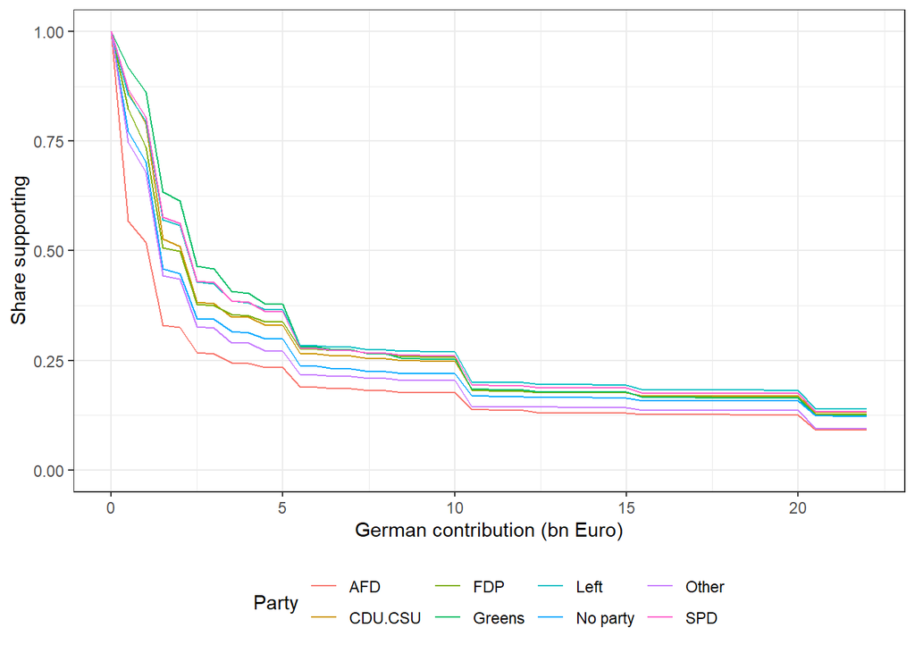

```r
supports_by_party
```

# 10 Figure 7: Levels of support by migration background

```r
sm <- lapply(0:1, function(m)
  support(
    df_4 %>% dplyr::filter(migration_background == m) %>% pull(cash_billions),
    amounts = amounts_d))
names(sm) <- c("Non migrant", "Migrant")

sm <- sm %>% bind_rows(.id = "Migration_background")

supports_by_migration <-
  sm %>% ggplot(aes(amounts, support, color = Migration_background)) + geom_line() + ylim(0,1) + theme_bw() + xlab("German contribution (bn Euro)") + ylab("Share supporting")  + theme(legend.position="bottom")

pdf("2_output/cumulative_by_migration.pdf", height = 6, width = 10)
 supports_by_migration
dev.off()
```

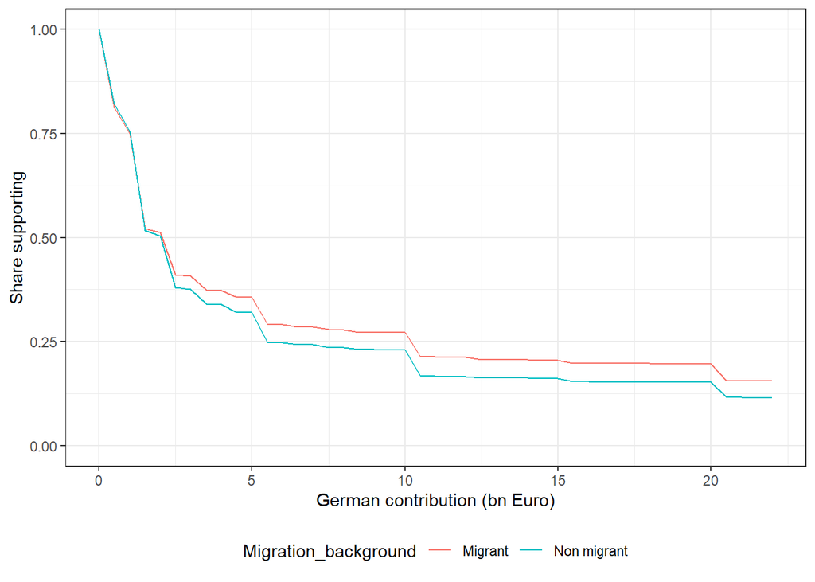

```r
supports_by_migration
```

# 11 Figure 8: Marginal effects of conditions by party

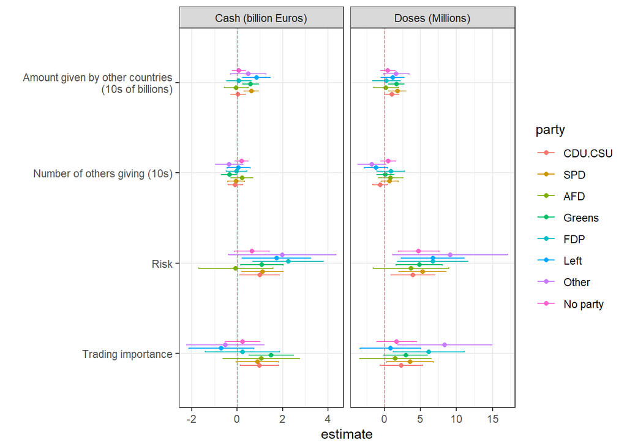

```r
main_results_by_party <-
  lapply(unique(df_4$party), function(p)
    list(
      cash = lm_robust(cash_billions ~ trading_importance*risk*others_number_norm*others_giving_norm  + round,
                       fixed_effects = ~id,  se_type = "stata",
                       data = df_4 %>% dplyr::filter(party == p)) %>% tidy,
      doses = lm_robust(doses ~ trading_importance*risk*others_number_norm*others_giving_norm  + round,
                        fixed_effects = ~id,  se_type = "stata",
                        data = df_4 %>% dplyr::filter(party == p)) %>% tidy) %>%
      bind_rows() %>% mutate(party = p)) %>%
  bind_rows()

figure_1_party <-

  main_results_by_party %>%
  dplyr::filter(term %in% treatments_norm) %>%
  mutate(Treatment = factor(term, treatments_norm, treatment_labels),
         outcome = factor(outcome, c("cash_billions", "doses"), c("Cash (billion Euros)", "Doses (Millions)"))) %>%

  ggplot(aes(Treatment, estimate, color = party)) +
  geom_point(position = position_dodge(0.3))+
  geom_errorbar(aes(ymin = conf.low, ymax = conf.high), position = position_dodge(0.3), width = .1)+
  geom_hline(yintercept=0, linetype="longdash", lwd=0.35, colour = "#B55555") +
  theme_bw() + facet_grid(~outcome, scales = "free_x")+
  xlab("") +
  coord_flip()

figure_1_party
```

```r
pdf("2_output/figure_1_party.pdf", width = 9, height = 7)
 figure_1_party
dev.off()
```

# 12 Figure 9: Marginal effects of conditions by migration background

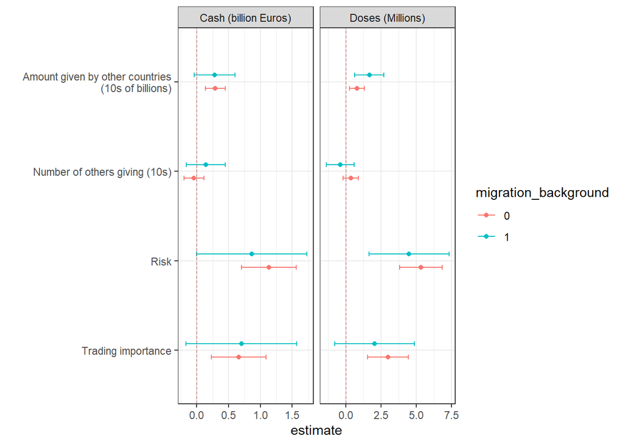

```r
main_results_by_background <-
  lapply(unique(df_4$migration_background), function(p)
    list(
      cash = lm_robust(cash_billions ~ trading_importance*risk*others_number_norm*others_giving_norm  + round,
                       fixed_effects = ~id,  se_type = "stata",
                       data = df_4 %>% dplyr::filter(migration_background == p)) %>% tidy,
      doses = lm_robust(doses ~ trading_importance*risk*others_number_norm*others_giving_norm  + round,
                        fixed_effects = ~id,  se_type = "stata",
                        data = df_4 %>% dplyr::filter(migration_background == p)) %>% tidy) %>%
      bind_rows() %>% mutate(migration_background = factor(p))) %>%
  bind_rows()

figure_1_background <-

  main_results_by_background %>%
  dplyr::filter(term %in% treatments_norm) %>%
  mutate(Treatment = factor(term, treatments_norm, treatment_labels),
         outcome = factor(outcome, c("cash_billions", "doses"), c("Cash (billion Euros)", "Doses (Millions)"))) %>%

  ggplot(aes(Treatment, estimate, color = migration_background)) +
  geom_point(position = position_dodge(0.3))+
  geom_errorbar(aes(ymin = conf.low, ymax = conf.high), position = position_dodge(0.3), width = .1)+
  geom_hline(yintercept=0, linetype="longdash", lwd=0.35, colour = "#B55555") +
  theme_bw() + facet_grid(~outcome, scales = "free_x")+
  xlab("") +
  coord_flip()

figure_1_background
```

```r
pdf("2_output/figure_1_background.pdf", width = 9, height = 4)
 figure_1_background
dev.off()
```

# 13 Figure 10: Results Refreshment Sample

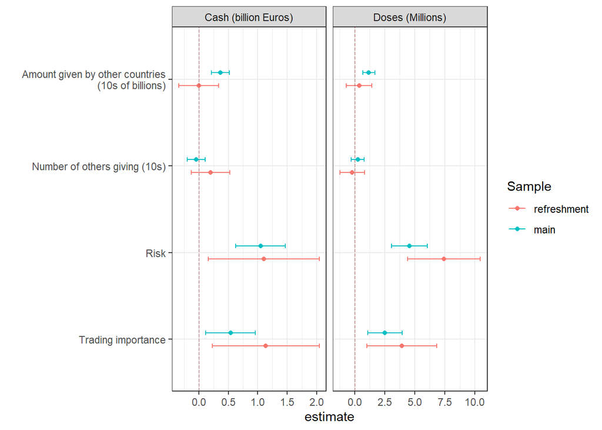

```r
# 5.2 Main results by group
main_results_by_group <-
  lapply(unique(df_4$group), function(p)
    list(
      cash = lm_robust(cash_billions ~ trading_importance*risk*others_number_norm*others_giving_norm  + round,
                       fixed_effects = ~id,  se_type = "stata",
                       data = df_4 %>% dplyr::filter(group == p)) %>% tidy,
      doses = lm_robust(doses ~ trading_importance*risk*others_number_norm*others_giving_norm  + round,
                        fixed_effects = ~id,  se_type = "stata",
                        data = df_4 %>% dplyr::filter(group == p)) %>% tidy) %>%
      bind_rows() %>% mutate(group = factor(p))) %>%
  bind_rows()

figure_1_group <-

  main_results_by_group %>%
  dplyr::filter(term %in% treatments_norm) %>%
  mutate(Treatment = factor(term, treatments_norm, treatment_labels),
         outcome = factor(outcome, c("cash_billions", "doses"), c("Cash (billion Euros)", "Doses (Millions)"))) %>%
  ggplot(aes(Treatment, estimate, group=group, color = group)) +
  geom_point(position = position_dodge(0.3))+
  scale_color_discrete(name = "Sample", labels = c("refreshment", "main"))+
  geom_errorbar(aes(ymin = conf.low, ymax = conf.high), position = position_dodge(0.3), width = .1)+
  geom_hline(yintercept=0, linetype="longdash", lwd=0.35, colour = "#B55555") +
  theme_bw() + facet_grid(~outcome, scales = "free_x")+
  xlab("") +
  coord_flip()

figure_1_group
```

```r
pdf("2_output/figure_1_group.pdf", width = 9, height = 4)
figure_1_group
dev.off()
```

# 14 Additional Analyses

## 14.1 Individual solidarity

Should an older Indian woman be prioritized over a young German?

```r
## Prioritization analysis

df_4 <- df_4 %>% mutate(
    de_de_preference  = perspective_fed_german - perspective_fed_indian # DE Preference for German 25
)

df_4 %>%
  summarize(
    priority_de_indian = mean(perspective_fed_indian),
    priority_de_german = mean(perspective_fed_german),
 #   priority_who_indian = mean(perspective_who_indian),
#    priority_who_german = mean(perspective_who_german),
    de_ind_preference  = mean(perspective_fed_german <= perspective_fed_indian),
    de_ind_preference2  = mean(perspective_fed_german < perspective_fed_indian),
    de_ind_preference3  = mean(perspective_fed_german == perspective_fed_indian),
 #   who = mean(who_de_preference, na.rm = TRUE),
 #   who_priority = mean(who_de_preference>0, na.rm = TRUE)
    ) %>% t %>% kable(format = "pipe")
```

| priority_de_indian | 4.3993349 |
| --- | --- |
| priority_de_german | 4.6817102 |
| de_ind_preference | 0.5696912 |
| de_ind_preference2 | 0.3832779 |
| de_ind_preference3 | 0.1864133 |

```r
M <-
  lm_robust(cash_billions_log ~  perspective_fed_german + perspective_fed_indian, data = df_4)
M %>% tidy %>% kable(digits = 2)
```

| term | estimate | std.error | statistic | p.value | conf.low | conf.high | df | outcome |
| --- | --- | --- | --- | --- | --- | --- | --- | --- |
| (Intercept) | 0.89 | 0.04 | 20.45 | 0 | 0.81 | 0.98 | 21047 | cash_billions_log |
| perspective_fed_german | 0.02 | 0.01 | 4.10 | 0 | 0.01 | 0.03 | 21047 | cash_billions_log |
| perspective_fed_indian | 0.09 | 0.01 | 16.57 | 0 | 0.08 | 0.10 | 21047 | cash_billions_log |

```r
# M$r.squared
# plot(df_4$cash_billions_log, df_4$perspective_fed_indian)
```

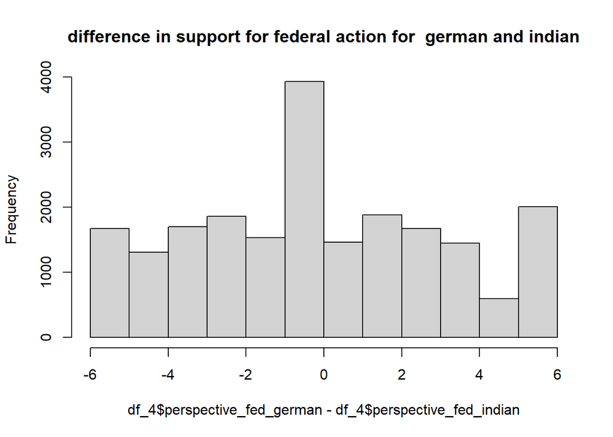

```r
hist(df_4$perspective_fed_german - df_4$perspective_fed_indian,
     main = "difference in support for federal action for  german and indian")
```

```r
lm_robust(log(cash_billions+1) ~ trading_factor*risk_factor+ treatment_video + round + perspective_fed_german +perspective_fed_indian,  se_type = "stata", data = df_4) %>% tidy  %>%
  kbl(digit =2) %>%
  kable_minimal()
```

| term | estimate | std.error | statistic | p.value | conf.low | conf.high | df | outcome |
| --- | --- | --- | --- | --- | --- | --- | --- | --- |
| (Intercept) | 0.84 | 0.06 | 14.26 | 0.00 | 0.72 | 0.95 | 16792 | log(cash_billions + 1) |
| trading_factorHigh | 0.01 | 0.03 | 0.58 | 0.56 | -0.04 | 0.07 | 16792 | log(cash_billions + 1) |
| risk_factorHigh | 0.09 | 0.03 | 3.57 | 0.00 | 0.04 | 0.15 | 16792 | log(cash_billions + 1) |
| treatment_video | 0.01 | 0.02 | 0.30 | 0.76 | -0.03 | 0.04 | 16792 | log(cash_billions + 1) |
| round | 0.02 | 0.02 | 0.83 | 0.41 | -0.02 | 0.05 | 16792 | log(cash_billions + 1) |
| perspective_fed_german | 0.02 | 0.01 | 2.98 | 0.00 | 0.01 | 0.03 | 16792 | log(cash_billions + 1) |
| perspective_fed_indian | 0.08 | 0.01 | 14.30 | 0.00 | 0.07 | 0.09 | 16792 | log(cash_billions + 1) |
| trading_factorHigh:risk_factorHigh | -0.04 | 0.04 | -1.12 | 0.26 | -0.11 | 0.03 | 16792 | log(cash_billions + 1) |

```r
raw  <-
  df_4 %>%
  mutate(costs = ((risk_factor == "High") + 2*(trading_factor=="High"))) %>%
  group_by(trading_factor, risk, deal, costs) %>%
  summarize(cash_bn = median(cash_billions, na.rm = TRUE),
            doses = median(doses, na.rm = TRUE))  %>%
  gather("outcome","value",  -risk,  -deal, -trading_factor, -costs)

medians_plot <-
raw %>% ggplot(aes(risk, value, color = trading_factor)) +
  facet_grid(outcome ~ deal, scales = "free_y") + geom_point()  + geom_line() + ylim(c(0, NA)) + theme_bw() + ylab(" ")+
  scale_x_continuous(breaks=c(-.45,.45), labels = c("Low", "High"))

pdf("2_output/medians.pdf", height = 5, width = 8)
 medians_plot
dev.off()
```

```r
# Note: use bootstrapping to add standard errors on the median?



observation_plot <- function(data = df_4)
data %>% dplyr::select(risk_factor, deal, trading_factor, cash_billions, doses, vaccinated) %>%
  mutate(cash_billions = ifelse(cash_billions>20, 20, cash_billions)) %>%
  gather("outcome","value",  -risk_factor,  -deal, -trading_factor, - vaccinated) %>%
  mutate(outcome = factor(outcome, c("cash_billions", "doses"), c("Billion Euros", "Million doses"))) %>%
  ggplot(aes(risk_factor, value, color = trading_factor)) + facet_grid(outcome ~ deal, scales = "free_y") +
  geom_boxplot() + ylim(c(0, NA)) + theme_bw() +
  scale_y_continuous(trans='sqrt') +
  ylab(" ") + xlab("Mutation risk")


observation_plot
```

```
function(data = df_4)
data %>% dplyr::select(risk_factor, deal, trading_factor, cash_billions, doses, vaccinated) %>%
  mutate(cash_billions = ifelse(cash_billions>20, 20, cash_billions)) %>%
  gather("outcome","value",  -risk_factor,  -deal, -trading_factor, - vaccinated) %>%
  mutate(outcome = factor(outcome, c("cash_billions", "doses"), c("Billion Euros", "Million doses"))) %>%
  ggplot(aes(risk_factor, value, color = trading_factor)) + facet_grid(outcome ~ deal, scales = "free_y") +
  geom_boxplot() + ylim(c(0, NA)) + theme_bw() +
  scale_y_continuous(trans='sqrt') +
  ylab(" ") + xlab("Mutation risk")
```

## 14.2 Wave 2 conjoint

A conjoint was also implemented in Wave 2 but with a flawed design. The wave 2 values were poorly calibrated and question wording left ambiguity regarding beneficiaries as the benefits conditions are conceptually confused with numbers conditions.

Analysis is implemented and reported here in the interests of completeness.

```r
label <- "1_input/W2_exp3_vignettes_universe.dta" %>%
  read_dta() %>%
    mutate(vignr = as.numeric(vignr))


# label |>  head() |> kable(caption = "W2 vignettes")


conjoints <-

  list(
    conjoint1_1 =
      df_2 %>%
      mutate(vignr = as.numeric(c_0031_w2),
             outcome = conjoint_choice1_exp3,
             rating = conjoint_rating1_exp3,
             contest = 1, candidate=1),

  conjoint1_2 =
      df_2 %>%
      mutate(vignr = as.numeric(c_0032_w2),
             outcome = conjoint_choice1_exp3,
             rating = conjoint_rating2_exp3,
             contest = 1, candidate=2),

  conjoint2_1 =
      df_2 %>%
      mutate(vignr = as.numeric(vignette3),
             outcome = conjoint_choice2_exp3,
             rating = conjoint_rating3_exp3,
             contest = 2, candidate=1),

    conjoint2_2 =
      df_2 %>%
      mutate(vignr = as.numeric(vignette4),
             outcome = conjoint_choice2_exp3,
             rating = conjoint_rating4_exp3,
             contest = 2, candidate=2),

  conjoint3_1 =
      df_2 %>%
      mutate(vignr = as.numeric(vignette5),
             outcome = conjoint_choice3_exp3,
             rating = conjoint_rating5_exp3,
             contest = 3, candidate=1),

  conjoint3_2 =
      df_2 %>%
      mutate(vignr = as.numeric(vignette6),
             outcome = conjoint_choice3_exp3,
             rating = conjoint_rating6_exp3,
             contest = 3, candidate=2)

) %>%
  bind_rows() %>%
  select(ID, vignr, outcome, rating, contest, candidate, treatment_video) %>%
  mutate(
    outcome = ifelse(candidate ==1,
                     as.numeric(outcome=="1"),
                     as.numeric(outcome=="2"))) %>%
  left_join(label) %>%
  mutate(
    doses = factor(
      vig_doses, 0:3,
      c("1 Million doses", "5 Million doses", "10 Million doses", "20 Million doses")),
    share = factor(vig_dose_share, 0:3,
      c("1 % of the vaccines", "5 % of the vaccines", "10 % of the vaccines", "20 % of the vaccines")),
    number= factor(vig_countries, 0:2, c("20 countries", "80 countries", "160 countries")),
    economic_benefits= factor(vig_benefit_economic, 0:1, c("Without economic importance", "With economic importance")),
    health_benefits=factor(vig_benefit_health, 0:1,
      c("No risk of infection", "Risk of infection")))

# Demean data
# Note that mean rating is removed
conjoints_norm <- conjoints %>%
  mutate(doses_norm = vig_doses - mean(vig_doses),
         number_norm = vig_countries - mean(vig_countries),
         share_norm = vig_dose_share - mean(vig_dose_share),
         economic_benefits = vig_benefit_economic - mean(vig_benefit_economic),
         health_benefits = vig_benefit_health - mean(vig_benefit_health)) %>%
  group_by(ID) %>%
  mutate(rating = rating - mean(rating)) %>% ungroup


models_interactions <-
  list(
    rating0 = lm_robust(rating ~  doses_norm*share_norm*number_norm*economic_benefits*health_benefits, data = conjoints_norm),
    rating1 = lm_robust(rating ~  doses_norm*share_norm*number_norm*economic_benefits*health_benefits, data = conjoints_norm),
    choice0 = lm_robust(outcome ~  doses_norm*share_norm*number_norm*economic_benefits*health_benefits, data = conjoints_norm),
    choice1 = lm_robust(outcome ~  doses_norm*share_norm*number_norm*economic_benefits*health_benefits, data = conjoints_norm)
  )


models_treatments <-
  list(
    rating = lm_robust(rating ~  treatment_video*vig_doses + treatment_video*vig_dose_share + treatment_video*vig_countries + treatment_video*vig_benefit_economic + treatment_video*vig_benefit_health,
                        data = conjoints_norm),
    choice = lm_robust(outcome ~  treatment_video*vig_doses + treatment_video*vig_dose_share + treatment_video*vig_countries + treatment_video*vig_benefit_economic + treatment_video*vig_benefit_health,
                        data = conjoints_norm)
    )

htmlreg(models_interactions)
```

Statistical models

|  | rating0 | rating1 | choice0 | choice1 |
| --- | --- | --- | --- | --- |
| (Intercept) | -0.00 | -0.00 | 0.50* | 0.50* |
|  | [-0.01; 0.01] | [-0.01; 0.01] | [ 0.50; 0.50] | [ 0.50; 0.50] |
| doses_norm | -0.07* | -0.07* | -0.02* | -0.02* |
|  | [-0.08; -0.06] | [-0.08; -0.06] | [-0.02; -0.02] | [-0.02; -0.02] |
| share_norm | -0.09* | -0.09* | -0.02* | -0.02* |
|  | [-0.10; -0.08] | [-0.10; -0.08] | [-0.02; -0.02] | [-0.02; -0.02] |
| number_norm | 0.21* | 0.21* | 0.07* | 0.07* |
|  | [ 0.20; 0.23] | [ 0.20; 0.23] | [ 0.06; 0.07] | [ 0.06; 0.07] |
| economic_benefits | -0.21* | -0.21* | -0.06* | -0.06* |
|  | [-0.24; -0.19] | [-0.24; -0.19] | [-0.06; -0.05] | [-0.06; -0.05] |
| health_benefits | 0.11* | 0.11* | 0.03* | 0.03* |
|  | [ 0.08; 0.13] | [ 0.08; 0.13] | [ 0.02; 0.04] | [ 0.02; 0.04] |
| doses_norm:share_norm | -0.01 | -0.01 | -0.00 | -0.00 |
|  | [-0.02; 0.00] | [-0.02; 0.00] | [-0.01; 0.00] | [-0.01; 0.00] |
| doses_norm:number_norm | -0.01 | -0.01 | -0.00* | -0.00* |
|  | [-0.03; 0.00] | [-0.03; 0.00] | [-0.01; -0.00] | [-0.01; -0.00] |
| share_norm:number_norm | -0.00 | -0.00 | -0.00 | -0.00 |
|  | [-0.02; 0.01] | [-0.02; 0.01] | [-0.00; 0.00] | [-0.00; 0.00] |
| doses_norm:economic_benefits | -0.01 | -0.01 | -0.00 | -0.00 |
|  | [-0.04; 0.01] | [-0.04; 0.01] | [-0.01; 0.00] | [-0.01; 0.00] |
| share_norm:economic_benefits | 0.02 | 0.02 | 0.00 | 0.00 |
|  | [-0.00; 0.05] | [-0.00; 0.05] | [-0.00; 0.01] | [-0.00; 0.01] |
| number_norm:economic_benefits | -0.01 | -0.01 | -0.01 | -0.01 |
|  | [-0.04; 0.03] | [-0.04; 0.03] | [-0.02; 0.00] | [-0.02; 0.00] |
| doses_norm:health_benefits | 0.00 | 0.00 | 0.00 | 0.00 |
|  | [-0.02; 0.03] | [-0.02; 0.03] | [-0.00; 0.01] | [-0.00; 0.01] |
| share_norm:health_benefits | -0.01 | -0.01 | -0.00 | -0.00 |
|  | [-0.03; 0.02] | [-0.03; 0.02] | [-0.01; 0.00] | [-0.01; 0.00] |
| number_norm:health_benefits | -0.00 | -0.00 | -0.01 | -0.01 |
|  | [-0.04; 0.03] | [-0.04; 0.03] | [-0.01; 0.00] | [-0.01; 0.00] |
| economic_benefits:health_benefits | 0.10* | 0.10* | 0.01 | 0.01 |
|  | [ 0.04; 0.15] | [ 0.04; 0.15] | [-0.00; 0.02] | [-0.00; 0.02] |
| doses_norm:share_norm:number_norm | -0.01 | -0.01 | -0.00 | -0.00 |
|  | [-0.03; 0.00] | [-0.03; 0.00] | [-0.01; 0.00] | [-0.01; 0.00] |
| doses_norm:share_norm:economic_benefits | -0.00 | -0.00 | 0.00 | 0.00 |
|  | [-0.02; 0.02] | [-0.02; 0.02] | [-0.00; 0.01] | [-0.00; 0.01] |
| doses_norm:number_norm:economic_benefits | -0.02 | -0.02 | -0.00 | -0.00 |
|  | [-0.05; 0.01] | [-0.05; 0.01] | [-0.01; 0.00] | [-0.01; 0.00] |
| share_norm:number_norm:economic_benefits | -0.00 | -0.00 | -0.00 | -0.00 |
|  | [-0.03; 0.03] | [-0.03; 0.03] | [-0.01; 0.00] | [-0.01; 0.00] |
| doses_norm:share_norm:health_benefits | 0.01 | 0.01 | -0.00 | -0.00 |
|  | [-0.02; 0.03] | [-0.02; 0.03] | [-0.01; 0.00] | [-0.01; 0.00] |
| doses_norm:number_norm:health_benefits | 0.02 | 0.02 | -0.00 | -0.00 |
|  | [-0.02; 0.05] | [-0.02; 0.05] | [-0.01; 0.01] | [-0.01; 0.01] |
| share_norm:number_norm:health_benefits | -0.01 | -0.01 | -0.00 | -0.00 |
|  | [-0.04; 0.02] | [-0.04; 0.02] | [-0.01; 0.01] | [-0.01; 0.01] |
| doses_norm:economic_benefits:health_benefits | -0.02 | -0.02 | 0.00 | 0.00 |
|  | [-0.07; 0.03] | [-0.07; 0.03] | [-0.01; 0.01] | [-0.01; 0.01] |
| share_norm:economic_benefits:health_benefits | -0.00 | -0.00 | -0.00 | -0.00 |
|  | [-0.05; 0.05] | [-0.05; 0.05] | [-0.02; 0.01] | [-0.02; 0.01] |
| number_norm:economic_benefits:health_benefits | 0.05 | 0.05 | 0.01 | 0.01 |
|  | [-0.02; 0.12] | [-0.02; 0.12] | [-0.01; 0.03] | [-0.01; 0.03] |
| doses_norm:share_norm:number_norm:economic_benefits | 0.01 | 0.01 | 0.00 | 0.00 |
|  | [-0.02; 0.04] | [-0.02; 0.04] | [-0.00; 0.01] | [-0.00; 0.01] |
| doses_norm:share_norm:number_norm:health_benefits | 0.01 | 0.01 | 0.00 | 0.00 |
|  | [-0.02; 0.04] | [-0.02; 0.04] | [-0.01; 0.01] | [-0.01; 0.01] |
| doses_norm:share_norm:economic_benefits:health_benefits | -0.01 | -0.01 | -0.01 | -0.01 |
|  | [-0.05; 0.04] | [-0.05; 0.04] | [-0.02; 0.01] | [-0.02; 0.01] |
| doses_norm:number_norm:economic_benefits:health_benefits | 0.05 | 0.05 | 0.01 | 0.01 |
|  | [-0.01; 0.11] | [-0.01; 0.11] | [-0.00; 0.03] | [-0.00; 0.03] |
| share_norm:number_norm:economic_benefits:health_benefits | 0.01 | 0.01 | 0.01 | 0.01 |
|  | [-0.06; 0.07] | [-0.06; 0.07] | [-0.01; 0.02] | [-0.01; 0.02] |
| doses_norm:share_norm:number_norm:economic_benefits:health_benefits | -0.04 | -0.04 | -0.01 | -0.01 |
|  | [-0.10; 0.01] | [-0.10; 0.01] | [-0.02; 0.00] | [-0.02; 0.00] |
| R<sup>2</sup> | 0.01 | 0.01 | 0.02 | 0.02 |
| Adj. R<sup>2</sup> | 0.01 | 0.01 | 0.02 | 0.02 |
| Num. obs. | 82692 | 82692 | 82692 | 82692 |
| RMSE | 2.03 | 2.03 | 0.49 | 0.49 |

* Null hypothesis value outside the confidence interval.

```r
htmlreg(models_treatments)
```

Statistical models

|  | rating | choice |
| --- | --- | --- |
| (Intercept) | 0.17* | 0.53* |
|  | [ 0.12; 0.23] | [ 0.52; 0.54] |
| treatment_video | -0.19* | -0.04* |
|  | [-0.27; -0.11] | [-0.06; -0.02] |
| vig_doses | -0.10* | -0.03* |
|  | [-0.12; -0.08] | [-0.03; -0.03] |
| vig_dose_share | -0.10* | -0.02* |
|  | [-0.11; -0.08] | [-0.03; -0.02] |
| vig_countries | 0.17* | 0.06* |
|  | [ 0.14; 0.19] | [ 0.05; 0.06] |
| vig_benefit_economic | -0.21* | -0.05* |
|  | [-0.25; -0.17] | [-0.06; -0.04] |
| vig_benefit_health | 0.13* | 0.04* |
|  | [ 0.09; 0.17] | [ 0.03; 0.05] |
| treatment_video:vig_doses | 0.06* | 0.02* |
|  | [ 0.03; 0.08] | [ 0.01; 0.03] |
| treatment_video:vig_dose_share | 0.02 | 0.00 |
|  | [-0.01; 0.04] | [-0.00; 0.01] |
| treatment_video:vig_countries | 0.10* | 0.02* |
|  | [ 0.06; 0.13] | [ 0.01; 0.03] |
| treatment_video:vig_benefit_economic | -0.01 | -0.01 |
|  | [-0.07; 0.04] | [-0.02; 0.01] |
| treatment_video:vig_benefit_health | -0.05 | -0.01* |
|  | [-0.10; 0.01] | [-0.03; -0.00] |
| R<sup>2</sup> | 0.02 | 0.02 |
| Adj. R<sup>2</sup> | 0.01 | 0.02 |
| Num. obs. | 82692 | 82692 |
| RMSE | 2.03 | 0.49 |

* Null hypothesis value outside the confidence interval.

```r
fileConn <- file("2_output/treatment_effects.tex")
writeLines(texreg(models_treatments, float.pos = "h!", include.ci = FALSE, caption = "Effects of treatment on drivers of support for agreements. ",
  custom.coef.map = list(
    "(Intercept)" = "Constant (Average rating)",
    "treatment_video" = "Video effect (given ungenerous agreement)",
    "vig_doses" = "German contribution",
    "vig_dose_share" = "German share",
"vig_countries" = "Number of donors",
"vig_benefit_economic" = "Economic benefits",
"vig_benefit_health" = "Health benefits",
"treatment_video:vig_doses" = "Video * Contribution",
"treatment_video:vig_dose_share" = "Video * Share",
"treatment_video:vig_countries" = "Video * Donors",
"treatment_video:vig_benefit_economic" = "Video * Economics",
"treatment_video:vig_benefit_health"= "Video * Health"
    ), digits = 3), fileConn)
close(fileConn)
```